# Report on biodiversity driver

Kang

5/31/2022

## 概述

本研究主要探究城市中各种因子对植物多样性格局的影响。 最最最主要的思路参考文献如下：

Kendal, D., Williams, N.S.G., Williams, K.J.H., 2012. Drivers of diversity and tree cover in gardens, parks and streetscapes in an Australian city. Urban Forestry & Urban Greening 11, 257–265. https://doi.org/10.1016/j.ufug.2012.03.005

Peng, Y., Mi, K., Wang, H., Liu, Z., Lin, Y., Sang, W., Cui, Q., 2019. Most suitable landscape patterns to preserve indigenous plant diversity affected by increasing urbanization: A case study of Shunyi District of Beijing, China. Urban Forestry & Urban Greening 38, 33–41. https://doi.org/10.1016/j.ufug.2018.11.004

如果能够在这个基础上有所突破当然就更好了。 目前的分析比较简单，主要是看了一些环境、社会、经济因子对样方水平植物多样性格局的影响。

## 分析和结果

生物多样性相关的指数主要是物种丰富度（richness）、丰度（abundance）、均匀度（evenness），而目前分析的影响因子主要包括：距城市中心的距离、地价、人口密度、样方水平上各种用地的面积占比，之后打算增加的影响因子包括家庭收入、教育水平、街区年代、各个尺度上的景观指数（这个可能非常费时间）等。 有些分析是针对全体植物的，有些是针对乔木或灌木的。因为乔木是按株数来测量丰度，而灌木是以面积作为丰度指标的，所以暂时未将两者融合。

先看现在单因素皮尔森分析的结果：

```r
knitr::kable(prsn.res)
```

| variable | plant_richness | tree_richness | tree_abundance | tree_evenness | shrub_richness | shrub_abundance | shrub_evenness |
| --- | --- | --- | --- | --- | --- | --- | --- |
| dist_ctr | 0.07 | 0.15 | 0.2* | -0.18* | 0.02 | 0.11 | 0.09 |
| land_price | -0.06 | -0.19* | -0.18* | 0.13 | -0.02 | -0.05 | -0.1 |
| pop_tot | 0.01 | -0.1 | -0.02 | -0.08 | 0.06 | -0.02 | -0.09 |
| agriculture | -0.09 | -0.09 | -0.12 | -0.01 | -0.04 | -0.07 | -0.1 |
| water_wetland | 0.01 | 0.13 | 0.12 | -0.07 | -0.09 | 0.16* | -0.25** |
| park | -0.03 | 0.09 | 0.31*** | -0.16 | -0.04 | 0.28*** | -0.04 |
| temple_shrine | 0.04 | 0.1 | 0.08 | -0.02 | -0.03 | -0.02 | -0.04 |
| cemetery | 0 | 0.05 | 0 | 0.04 | 0.03 | 0 | 0.01 |
| vacant | -0.04 | 0.04 | -0.01 | 0.07 | -0.01 | 0 | -0.02 |
| golf_course | -0.05 | -0.09 | -0.06 | NA | -0.04 | -0.06 | 0.09 |
| residential | 0.36*** | 0.1 | -0.07 | 0.14 | 0.44*** | -0.1 | 0.09 |
| multi_family residential | NA | NA | NA | NA | NA | NA | NA |
| institutional | -0.08 | -0.06 | -0.1 | 0.12 | -0.11 | 0.02 | -0.07 |
| transportation | -0.07 | -0.07 | -0.1 | 0.1 | -0.1 | 0 | -0.06 |
| commercial_neighbor | 0.04 | 0.06 | 0.31*** | -0.51*** | -0.04 | 0.15 | 0.02 |
| commercial_industrial | -0.25*** | -0.19* | -0.12 | -0.07 | -0.2* | -0.14 | 0.14 |

以及回归模型的结果如下。 关于回归模型的方法，简述如下： 以生物多样性相关指数为因变量，影响因子为自变量进行回归。当然，把所有因子都选入未必是最佳的策略，因此此处采用全子集回归方法进行模型筛选。这和你听过的“逐步回归”是类似的，不过它是测试了所有可能的自变量组合，看看哪个组合对因变量的回归最佳，以此选出“最优模型”。下表展示的就是最优模型的结果：

| variable | plant_richness | tree_richness | tree_abundance | tree_even | shrub_richness | shrub_abund | shrub_even |
| --- | --- | --- | --- | --- | --- | --- | --- |
| agriculture | -5.27 | -4.32* | -4.32* | 0.12 | NA | -6.6 | -0.12 |
| commercial_industrial | -5.87* | -4.62** | -4.62** | NA | -2.54 | -6.08 | 0.21* |
| dist_ctr | 0 | NA | NA | 0** | NA | 0 | NA |
| institutional | NA | -1.2 | -1.2 | 0.1 | NA | NA | 0.06 |
| land_price | NA | 0** | 0** | NA | NA | 0 | 0 |
| multi_family_residential | -2.94 | -1.44 | -1.44 | 0.13* | -1.61 | -2.62 | 0.18* |
| park | NA | NA | NA | 0.05 | NA | 10.32* | NA |
| pop_tot | -0.01 | -0.01 | -0.01 | 0 | NA | 0 | 0 |
| residential | 4.39** | NA | NA | 0.12** | 4.48*** | -1.46 | 0.15* |
| transportation | NA | -1.55 | -1.55 | 0.11* | NA | NA | 0.06 |

表中的数字是效应方向和大小，星号则是显不显著。 比如比较普遍的商业工业用地占比对指数的副作用，做个图看看：

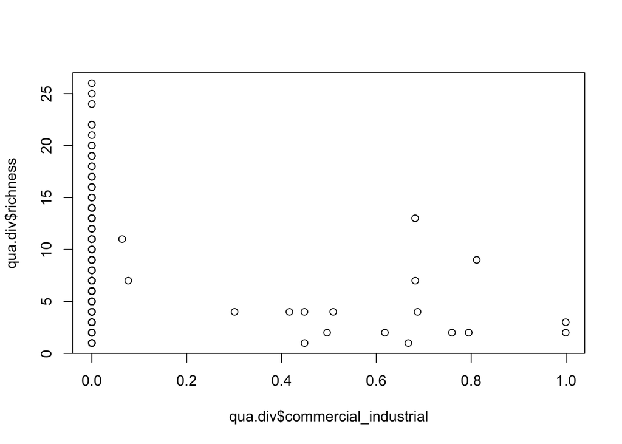

```r
plot(qua.div$commercial_industrial, qua.div$richness)
```

还有一个问题是皮尔森单因素的分析和回归模型（多因素）之间是有些冲突的，要考虑如何解决这个问题。

## 关于合作

好了要开始谈business了哈。 首先是是说双方的需求。我这边的主要动力是我一直很想看看京都市植物多样性和哪些因素有关，所以找之前先行研究验证过的一些因子来做测试，我觉得这样的研究能够为城市植物多样性格局的预测提供一些帮助，这是意义和兴趣所在。另一方面，我最近可能要找工作，感觉这个事情拖着就不知道要拖到什么时候了，想起你之前考虑过做红树林的生物多样性，于是感觉可以问问你是否有兴趣，如果有兴趣的话，就可以把这个事情逐渐推进下去。

从你的角度上看，不知道这个工作对于你毕业和以后工作是否有帮助，以及你是否感兴趣、有时间来一起做，这些问题可能需要你考虑一下。

合作分工的话，我的设想是：

我来做思路和概念框架、数据分析、大部分的可视化，并且参与部分前言的写作，因为我对数据和研究背景较熟悉。

你来主要负责写作，并且参与思路构建。

如果是这样的分工下，你就作为第一作者（或排名第一的共同第一作者），我作为通讯作者（或加上排名第二的共同第一作者，取决于实际合作中咱们贡献的情况），此外，加上阿柴作为第三作者。